# Informee

Stephany Michell Lobo Laguado

30/7/2021

## Integrantes

- Santiago Franco Valencia
- Isabela Lujan Jaramillo
- Ana María Sánchez Henao
- Daniel Alexander Naranjo Ríos
- Stephany Michell Lobo Laguado

## Integrantes

- Santiago Franco Valencia
- Isabela Lujan Jaramillo
- Ana María Sánchez Henao
- Daniel Alexander Naranjo Ríos
- Stephany Michell Lobo Laguado

## Objetivo

El objetivo de este trabajo es llevar a cabo un ejercicio de segmentación de clientes para una base de datos simulada de una empresa cuyos clientes son otras empresas. Se pretende proponer por medio de técnicas de aprendizaje no superviado, una segmentación que permita a la empresa entender mejor a sus clientes, identificar patrones de uso de productos y canales y su relación con los estados financieros.

## Introducción

Debido a las distintas necesidades de los consumidores en el mundo actual, las empresas se han visto frente a la necesidad de dividir y clasificar a sus clientes en diversos grupos de acuerdo a características o deseos similares con el fin de optimizar sus procesos de promoción y comercialización de los distintos productos o servicios.

La segmentación de clientes surge como una estrategia que permite a las empresas optimizar de buena manera sus recursos al momento de ofrecer productos, teniendo en cuenta las necesidades específicas de los distintos consumidores. Una segmentación de clientes permite a las empresas enfocar adecuadamente sus esfuerzos de promoción de productos en pequeños grupos de clientes cuyas necesidades se ajusten a los servicios que la empresa ofrece.

## Contextualización de los datos

El conjunto de datos utilizados es simulado, y está compuesto por dos distintos tipos de variables:

1. **De comportamiento de los clientes en los diferentes canales y productos de la empresa**

Hay hasta 10 distintos canales en los que se realizan acciones de entrada y salida. Estos se distinguen de acuerdo a las siguiente notación:

- en: entrada
- vm: valor medio anual
- tx: transacciones mensuales promedio
- sal: salida
- en_vm_canal…(1, 2, 3, 4, 5, 6, 7, 8, 9, 10, otros)
- en_tx_canal…(1, 2, 3, 4, 5, 6, 7, 8, 9, 10, otros)
- sal_vm_canal5…(5, 2, 8, otros)
- sal_tx_canal…(5, 2, 8, otros)
2. De estados financieros de los clientes
- impo_cv: [importaciones]/[compras] categorizadas
- expo_vt: [exportaciones]/[ventas] categorizadas
- cxp: [cuentas por pagar] categorizada con seis niveles
- cxc: [cuentas por cobrar] categorizada con seis niveles
- totalinventory: [valor de inventarios] categorizada con seis niveles
- pagos_pj: [pagos hechos a personas jurídicas]/[pagos totales]
- pagos_pn: [pagos hechos a personas naturales]/[pagos totales]
- tiene_ventas_fisicas: la empresa tiene puntos de venta físicos (1:Si, 0:No)
- tiene_ventas_electronicas: la empresa tiene ventas electrónicas (1:Si, 0:No)
- recaudos_pj: [recaudos provenientes de personas jurídicas]/[recaudos totales]
- recaudos_pn: [recaudos provenientes de personas naturales]/[recaudos totales]
- rotacion_inventarios: [rotación de inventarios en días] categorizada con seis niveles
- rotacion_cxc: [rotación de cuentas por pagar en días] categorizada con seis niveles
- rotacion_cxp: [rotación de cuentas por cobrar en días] categorizada con seis niveles
- ciclo_negocio: [ciclo de negocio en días] categorizada con seis niveles
- ciclo_financiero: [ciclo financiero en días] categorizada con seis niveles

## Funciones de Usuario

Estas funciones fueron creadas con el fin de depurar la base de datos realizando conteo de valores faltantes, reescalamiento de variables y nuevas variables.

```r
conteo <- function(columna){
        ### Contar los na de una columna
  return(sum(is.na(columna)))
}

min_max <- function(columna){
        # Reescalado min/max
  columna <- (columna-min(columna))/(max(columna)-min(columna))
  return(columna)
}
crearTabla <- function(variable1, variable2){
        # Creación de tablas de contingencia
  tabla <- table(variable1, variable2)
  nueva_tabla <- as.data.frame(tabla)
  grafica <- ggplot(data = nueva_tabla, mapping = aes(x=variable1, y=variable2, fill=Freq)) + geom_tile()
  return(grafica + scale_fill_gradient2(low = "white",  high = "red"))
}
segmentar_columna <- function(columna, percentiles){
  nueva <- columna
  nueva[nueva >0] <- findInterval(nueva[nueva>0],
                                  quantile(columna[columna >0], percentiles),
                                  all.inside = TRUE)
  return(nueva)
}
```

## Lectura de la base de datos

```r
base <- read.csv("base.csv", sep =";")
nits <- base$nit
base <- base[-1]
```

## Preprocesamiento de los datos

## Preprocesamiento variables númericas:

## Promedio de las respectivas transacciones en la base:

Se crean variables correspondientes al promedio de las transacciones diferentes en cada canal. Ya que cada entrada correspondiente a las transacciones representa la cantidad en promedio que se maneja de una transacción, se tiene que un 0 en la base de datos significa que no hubo transacciones en ese respectivo canal. Por lo que se cálcula el promedio de las transacciones que fueron mayores a 0, y el valor de 0 indica que no se hizo ninguna transacción de la que se intenta promediar.

Se toma el nombre de las variables correspondientes a cada transacción:

```r
salientes_tx <- grepl("sal_tx", names(base))
salientes_vm <- grepl("sal_vm", names(base))
entrantes_tx <- grepl("en_tx", names(base))
entrantes_vm <- grepl("en_vm", names(base))
```

Se convierten los 0’s a NA para poder aplicar un apply en las filas y se extrae la cantidad de NA’s en cada fila para estudiar el uso de cada canal:

```r
base[1:30][base[1:30] == 0] <- NA
conteo_nas <- apply(FUN = conteo, base, MARGIN = 2)
```

Se crean variables nuevas las cuales corresponden al promedio en cada transacción:

```r
promedio_salientes_tx <- apply(base[salientes_tx], MARGIN = 1, mean, na.rm = TRUE)
promedio_salientes_vm <- apply(base[salientes_vm], MARGIN = 1, mean, na.rm = TRUE)
promedio_entrantes_tx <- apply(base[entrantes_tx], MARGIN = 1, mean, na.rm = TRUE)
promedio_entrantes_vm <- apply(base[entrantes_vm], MARGIN = 1, mean, na.rm = TRUE)
```

Se crea un dataframe con las características encontradas en la base de datos y a cada valor faltante se le asigna un 0:

```r
caracteristicas <- data.frame(promedio_entrantes_tx, promedio_salientes_vm,
                   promedio_salientes_tx, promedio_entrantes_vm)
caracteristicas[is.na(caracteristicas)] <-0
```

Ya que se tienen distancias muy grandes entre observaciones, una medida que puede hacer que las distancias entre las observaciones sea más robusta es la transformación logarítmica:

```r
caracteristicas <- log(caracteristicas + 1)
```

```r
caracteristicas[1:4] <- apply(caracteristicas[1:4], MARGIN = 2, segmentar_columna, percentiles = seq(0, 1, by = 0.1))
```

### 2. Análisis de uso de los canales:

Ya que un valor de 0 en cada transacción significa que no hubo transacciones en un canal, se analiza el comportamiento de las transacciones realizadas por cada empresa, para encontrar cuales son canales más o menos frecuentados:

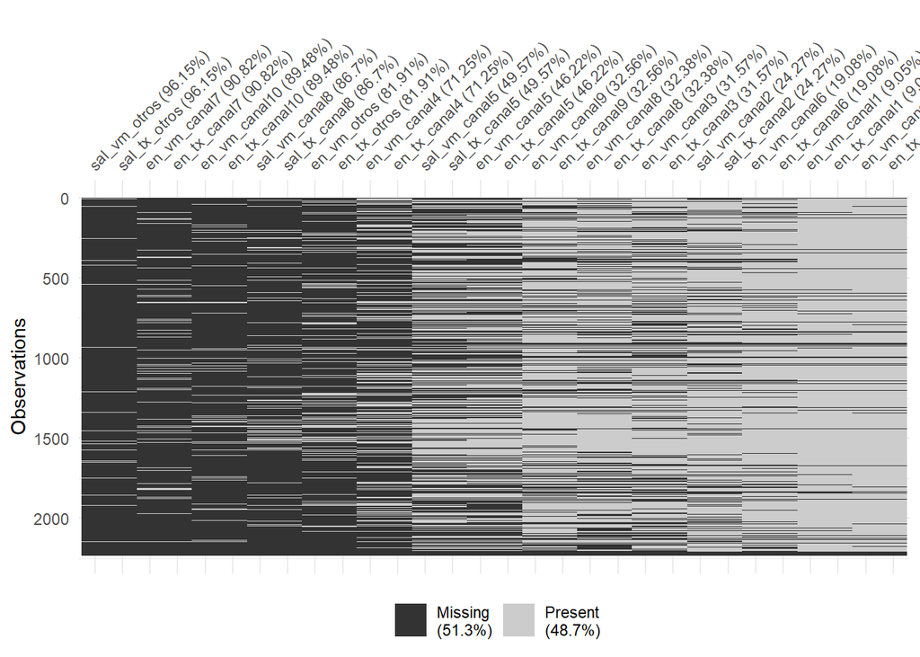

```r
base[1:30][base[1:30]==0] <- NA
vis_miss(base[1:30], sort_miss = TRUE)
```

A partir de la gráfica se observa que existen canales en donde menos del 30% de las empresas realizan transacciones, por lo que se sugiere la creación de una variable llamada poco_frecuentados, que indique sí se utilizaron aquellos canales que tuvieron muy poco uso:

```r
# Se calcula el porcentaje de valores faltantes en cada canal:
poco_frecuentados <- apply(base[1:30], MARGIN = 2, FUN = conteo)/2233
# Se seleccionan los canales cuyo uso es menor o igual al 30 %
poco_frecuentados <- poco_frecuentados[poco_frecuentados > 0.7]
poco_frecuentados <- names(poco_frecuentados)
# Aqui los conteo_nas NA vuelven a ser cero
base[is.na(base)] <- 0
# Se crea un vector llamado poco_frecuentados que condensa la información de los canales poco frecuentados
poco_frecuentados <- apply(base[poco_frecuentados], MARGIN = 1, mean)
poco_frecuentados[poco_frecuentados > 0] <- 1
head(poco_frecuentados)
```

```
## [1] 0 0 1 0 1 0
```

```r
poco <- as.data.frame(poco_frecuentados) %>%
  count(poco_frecuentados) %>%
  rename(uso_canal = poco_frecuentados, cuenta=n)
```

```r
kable(poco)
```

| uso_canal | cuenta |
| --- | --- |
| 0 | 1213 |
| 1 | 1020 |

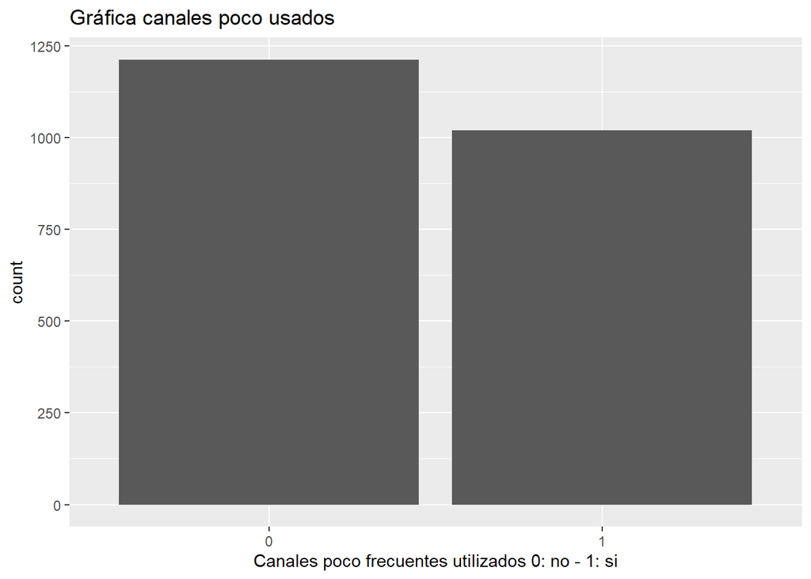

```r
ggplot(data = as.data.frame(poco_frecuentados)) +
  stat_count(mapping = aes(x = as.factor(poco_frecuentados))) +
  ggtitle("Gráfica canales poco usados") +
  xlab("Canales poco frecuentes utilizados 0: no - 1: si")
```

Como se evidencia en la gráfica y en la tabla de frecuencia, se puede observar que cerca de 1213 clientes de la base de datos NO utilizan los canales poco frecuentados, comparado frente a 1020 clientes que sí lo hacen.

## Variables categóricas

### Recaudos:

Realizando un análisis descriptivo previo se encontró que la mayoría de las empresas no hicieron recaudos, por lo que se crea la variable Recaudos para indicar qué empresas hicieron o no recaudos.

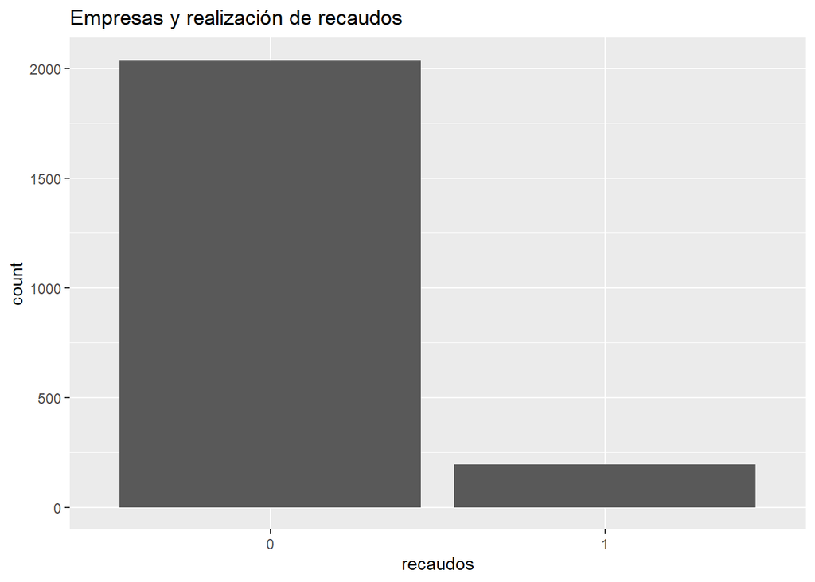

```r
recaudos <- grepl("recaudo", names(base))
recaudos <- apply(base[recaudos], MARGIN = 1, mean)
recaudos[recaudos > 0 ] <- 1
ggplot(data.frame(recaudos), aes(x = as.factor(recaudos))) + geom_bar() +
ggtitle("Empresas y realización de recaudos") +
xlab("recaudos")
```

### Pagos

Se procede a hallar la matriz de correlación entre los pagos a personas juridicas y los pagos a personas naturales:

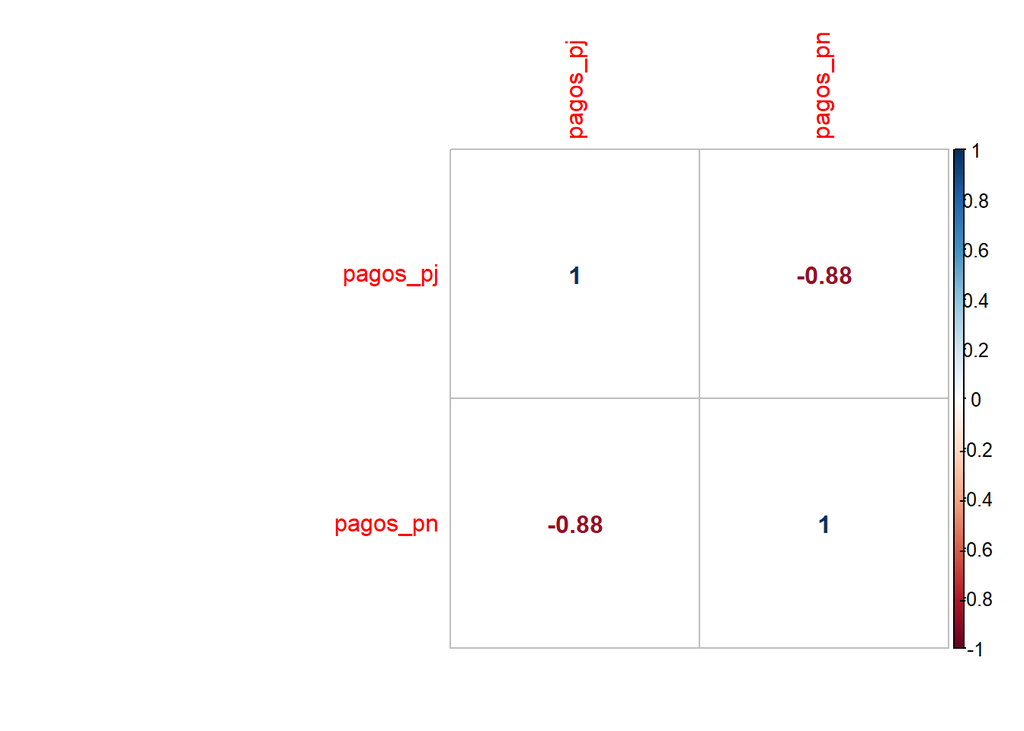

```r
pagos <- grepl("pagos", names(base))
correlaciones_pagos <- cor(base[pagos])
corrplot(correlaciones_pagos, method = "number")
```

En la matriz de correlación de las variables, se encuentra una alta correlación entre las variables pagos_pn y pagos_pj. Al observar su comportamiento se encuentra que una variable explica la otra, por lo que se considera solamente utilizar una sola variable para segmentar a los clientes:

```r
pagos_pn <- base$pagos_pn
```

### Tiene ventas físicas y/o digitales:

Para las variables tiene_ventas_fisicas y tiene_ventas_digitales, se crea una variable llamada tiene_ventas que cuyos valores corresponden a lo siguiente:

*0: La empresa no cuenta con un punto de venta.* 1: La empresa cuenta con al menos un punto de venta. *2: La empresa tiene puntos de venta tanto físicos como digitales.

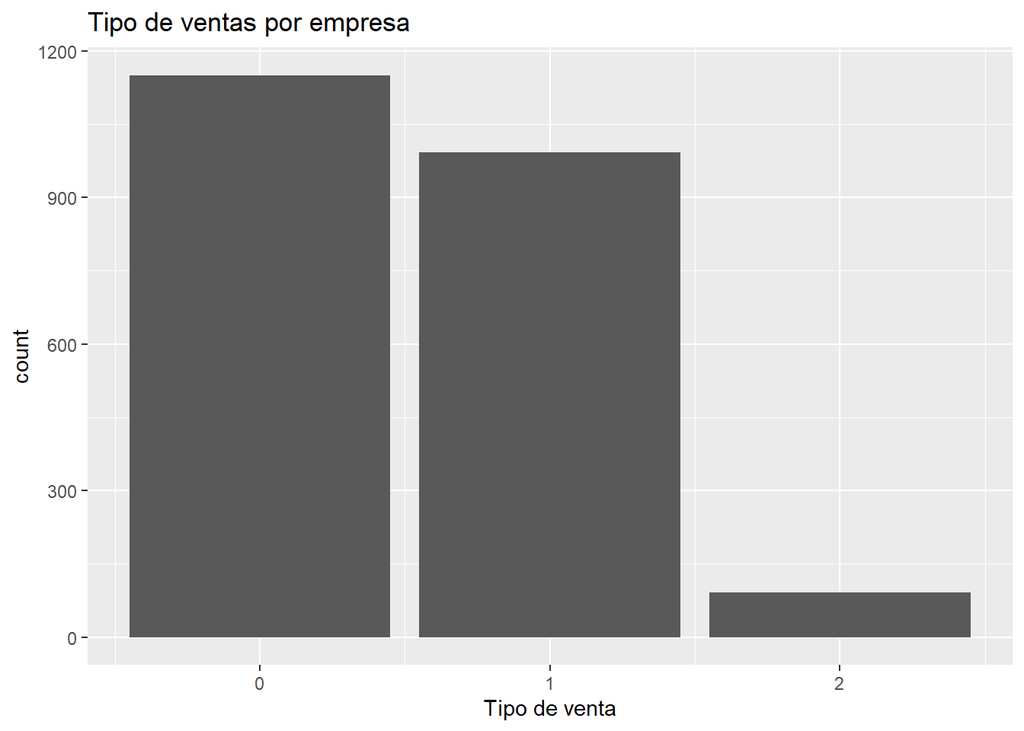

```r
tiene_ventas <- grepl("tiene_ventas", names(base))
tiene_ventas <- apply(base[tiene_ventas], MARGIN = 1, sum)
ggplot(data.frame(tiene_ventas), aes(x = tiene_ventas)) + geom_bar() +
ggtitle("Tipo de ventas por empresa") +
xlab("Tipo de venta")
```

Las demás variables de la base de datos, las cuales en el diccionario aparecen por niveles desde el 1 al 6, al ser ya categorizadas se dejarán tal y cómo están.

## Agrupamiento de variables:

Se agregan las demás variables categóricas a la base de características ya que al ser variables previamente categorizadas no sería consistente encontrar relaciones entre ellas ya que se desconoce su parte númerica.

```r
nombres_categoricas <- names(base[31:length(base)])
nombres <- grepl("recaudos|pagos|tiene", nombres_categoricas)
nombres_categoricas <- nombres_categoricas[!nombres]
```

```r
caracteristicas <- cbind(caracteristicas, base[nombres_categoricas], pagos_pn,
                         tiene_ventas, recaudos, poco_frecuentados)
kbl(caracteristicas) %>%
  kable_styling(bootstrap_options = c("striped", "hover", "condensed", "responsive")) %>%
  scroll_box("100%", height = "200px")
```

| promedio_entrantes_tx | promedio_salientes_vm | promedio_salientes_tx | promedio_entrantes_vm | impo_cv | expo_vt | cxp | cxc | totalinventory | rotacion_inventarios | rotacion_cxc | rotacion_cxp | ciclo_negocio | ciclo_financiero | pagos_pn | tiene_ventas | recaudos | poco_frecuentados |
| --- | --- | --- | --- | --- | --- | --- | --- | --- | --- | --- | --- | --- | --- | --- | --- | --- | --- |
| 0 | 0 | 0 | 0 | 1 | 1 | 6 | 6 | 6 | 6 | 2 | 2 | 5 | 6 | 0.000 | 0 | 0 | 0 |
| 0 | 0 | 0 | 0 | 1 | 1 | 2 | 6 | 2 | 1 | 3 | 1 | 3 | 4 | 0.000 | 0 | 0 | 0 |
| 6 | 7 | 7 | 6 | 1 | 1 | 3 | 1 | 2 | 2 | 1 | 2 | 2 | 1 | 0.544 | 1 | 0 | 1 |
| 3 | 1 | 2 | 1 | 2 | 2 | 1 | 1 | 1 | 5 | 2 | 3 | 5 | 5 | 0.385 | 1 | 0 | 0 |
| 6 | 5 | 4 | 2 | 1 | 1 | 2 | 2 | 2 | 2 | 2 | 1 | 3 | 3 | 0.000 | 1 | 0 | 1 |
| 2 | 8 | 5 | 1 | 1 | 1 | 1 | 3 | 1 | 1 | 4 | 1 | 5 | 5 | 0.410 | 0 | 0 | 0 |
| 1 | 5 | 1 | 8 | 1 | 1 | 1 | 4 | 1 | 2 | 4 | 1 | 6 | 6 | 0.000 | 0 | 0 | 0 |
| 0 | 0 | 0 | 0 | 2 | 2 | 2 | 1 | 6 | 6 | 1 | 1 | 6 | 6 | 0.000 | 0 | 0 | 0 |
| 9 | 0 | 0 | 2 | 2 | 2 | 3 | 1 | 4 | 6 | 1 | 4 | 6 | 5 | 0.000 | 1 | 0 | 1 |
| 3 | 6 | 10 | 5 | 2 | 2 | 3 | 6 | 3 | 1 | 3 | 1 | 4 | 4 | 1.000 | 0 | 0 | 0 |
| 6 | 4 | 2 | 5 | 1 | 1 | 1 | 2 | 2 | 2 | 2 | 1 | 3 | 4 | 0.259 | 1 | 0 | 1 |
| 10 | 9 | 10 | 8 | 2 | 2 | 6 | 4 | 4 | 1 | 1 | 1 | 2 | 2 | 0.938 | 1 | 0 | 1 |
| 7 | 5 | 6 | 6 | 4 | 2 | 3 | 3 | 3 | 5 | 3 | 4 | 5 | 5 | 0.481 | 1 | 0 | 1 |
| 2 | 5 | 2 | 5 | 2 | 2 | 2 | 3 | 2 | 2 | 3 | 1 | 4 | 4 | 0.377 | 0 | 0 | 0 |
| 9 | 6 | 5 | 8 | 2 | 2 | 2 | 4 | 2 | 2 | 3 | 1 | 4 | 5 | 0.614 | 0 | 0 | 1 |
| 2 | 1 | 3 | 2 | 2 | 2 | 1 | 2 | 2 | 3 | 3 | 1 | 4 | 5 | 0.291 | 0 | 0 | 1 |
| 7 | 1 | 1 | 3 | 2 | 2 | 4 | 3 | 3 | 5 | 3 | 4 | 5 | 3 | 0.000 | 1 | 0 | 1 |
| 4 | 3 | 4 | 2 | 2 | 2 | 4 | 4 | 2 | 2 | 4 | 4 | 5 | 3 | 0.535 | 1 | 0 | 1 |
| 8 | 6 | 9 | 5 | 1 | 1 | 3 | 3 | 2 | 2 | 2 | 2 | 3 | 2 | 0.805 | 0 | 0 | 0 |
| 2 | 3 | 5 | 4 | 1 | 1 | 1 | 2 | 4 | 6 | 3 | 2 | 6 | 6 | 0.645 | 0 | 0 | 0 |
| 1 | 1 | 3 | 2 | 1 | 1 | 2 | 1 | 2 | 3 | 1 | 4 | 3 | 1 | 0.662 | 0 | 0 | 0 |
| 5 | 0 | 0 | 5 | 3 | 2 | 2 | 3 | 2 | 3 | 3 | 2 | 4 | 4 | 0.038 | 0 | 0 | 0 |
| 5 | 3 | 4 | 4 | 4 | 3 | 2 | 2 | 2 | 3 | 2 | 1 | 4 | 5 | 0.455 | 0 | 0 | 0 |
| 10 | 0 | 0 | 10 | 2 | 2 | 6 | 6 | 3 | 1 | 2 | 2 | 2 | 2 | 0.233 | 1 | 1 | 1 |
| 4 | 2 | 4 | 2 | 1 | 1 | 1 | 2 | 1 | 2 | 4 | 3 | 5 | 5 | 0.912 | 1 | 0 | 0 |
| 9 | 5 | 7 | 4 | 2 | 2 | 2 | 3 | 2 | 2 | 4 | 4 | 5 | 2 | 0.720 | 1 | 1 | 1 |
| 7 | 8 | 10 | 7 | 2 | 2 | 1 | 3 | 1 | 1 | 2 | 1 | 2 | 3 | 0.954 | 1 | 1 | 1 |
| 0 | 0 | 0 | 0 | 3 | 3 | 4 | 6 | 6 | 6 | 3 | 1 | 6 | 6 | 0.796 | 0 | 0 | 0 |
| 7 | 9 | 9 | 10 | 3 | 3 | 6 | 6 | 6 | 2 | 2 | 2 | 3 | 3 | 0.444 | 0 | 0 | 0 |
| 8 | 4 | 6 | 3 | 1 | 1 | 2 | 2 | 2 | 2 | 1 | 2 | 2 | 2 | 0.663 | 0 | 0 | 0 |

[output cut: 2203 more lines]

## Método de agrupamiento no supervisado

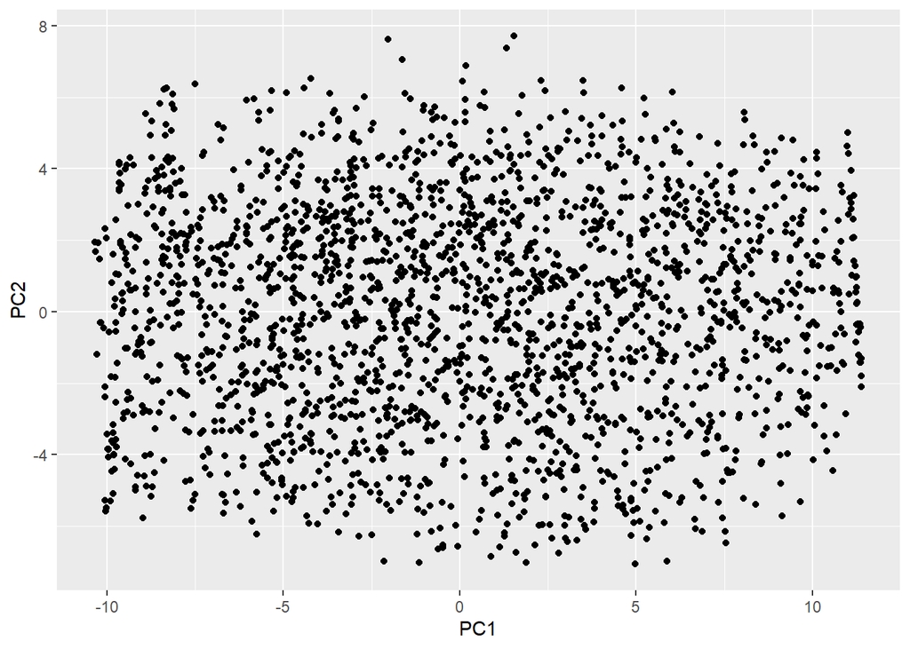

```r
componetes_principales <- prcomp(caracteristicas)
valores_componentes <- componetes_principales$x
valores_componentes<- as.data.frame(valores_componentes)
ggplot(valores_componentes, aes(x = PC1, y = PC2) ) + geom_point()
```

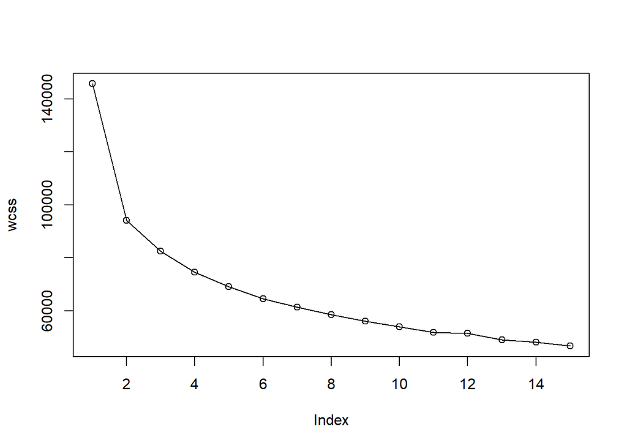

```r
set.seed(280721)
wcss <- vector()
for(i in 1:15){
  wcss[i] <- sum(kmeans(caracteristicas, i)$withinss)
}
plot(wcss, type = "ol")
```

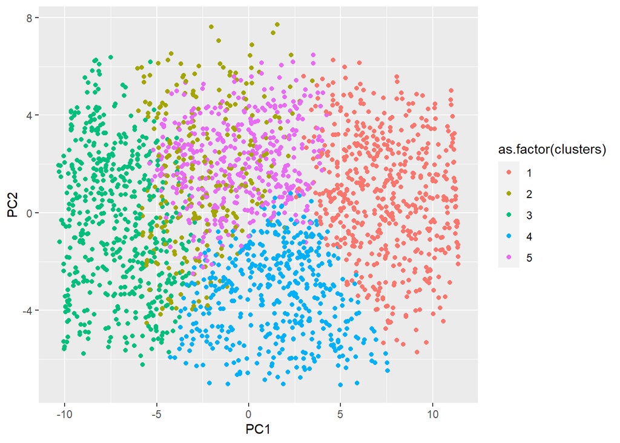

```r
set.seed(280721)
kmeans_datos <- kmeans(caracteristicas, 5, iter.max =1000, nstart = 10)
clusters <- kmeans_datos$cluster
valores_componentes$clusters <- clusters
ggplot(valores_componentes, aes(x = PC1, y = PC2, col = as.factor(clusters)) ) + geom_point()
```

```r
clusters_tabla <- as.data.frame(clusters) %>%
  count(clusters) %>%
  rename(total_clientes = n)
kbl(clusters_tabla) %>%
  kable_styling(bootstrap_options = c("striped", "hover", "condensed"))
```

| clusters | total_clientes |
| --- | --- |
| 1 | 550 |
| 2 | 269 |
| 3 | 537 |
| 4 | 450 |
| 5 | 427 |

```r
grupo1 <- caracteristicas[clusters == 1,]
grupo2 <- caracteristicas[clusters == 2,]
grupo3 <- caracteristicas[clusters == 3,]
grupo4 <- caracteristicas[clusters == 4,]
grupo5 <- caracteristicas[clusters == 5,]
```

## Comportamiento de clientes referente a las variables

## Comportamiento en variable promedio_entrantes_tx

```r
table(grupo1$promedio_entrantes_tx)
```

| 1 | 2 | 3 | 4 | 5 | 6 | 7 | 8 | 9 | 10 |
| --- | --- | --- | --- | --- | --- | --- | --- | --- | --- |
| 5 | 7 | 19 | 35 | 31 | 53 | 63 | 78 | 120 | 139 |

```r
table(grupo2$promedio_entrantes_tx)
```

| 1 | 2 | 3 | 4 | 5 | 6 | 7 | 8 | 9 | 10 |
| --- | --- | --- | --- | --- | --- | --- | --- | --- | --- |
| 19 | 12 | 18 | 19 | 30 | 38 | 35 | 36 | 36 | 26 |

```r
table(grupo3$promedio_entrantes_tx)
```

| 0 | 1 | 2 | 3 | 4 | 5 | 6 | 7 | 8 |
| --- | --- | --- | --- | --- | --- | --- | --- | --- |
| 145 | 144 | 100 | 65 | 39 | 27 | 11 | 5 | 1 |

```r
table(grupo4$promedio_entrantes_tx)
```

| 1 | 2 | 3 | 4 | 5 | 6 | 7 | 8 | 9 | 10 |
| --- | --- | --- | --- | --- | --- | --- | --- | --- | --- |
| 17 | 46 | 49 | 61 | 50 | 47 | 53 | 53 | 38 | 36 |

[figure not shown]

## Comportamiento en variable promedio_salientes_tx

```r
table(grupo1$promedio_salientes_tx)
```

| 1 | 2 | 3 | 4 | 5 | 6 | 7 | 8 | 9 | 10 |
| --- | --- | --- | --- | --- | --- | --- | --- | --- | --- |
| 1 | 16 | 15 | 15 | 27 | 40 | 61 | 95 | 130 | 150 |

```r
table(grupo2$promedio_salientes_tx)
```

| 0 | 1 | 2 | 3 | 4 | 5 |
| --- | --- | --- | --- | --- | --- |
| 124 | 72 | 49 | 18 | 5 | 1 |

```r
table(grupo3$promedio_salientes_tx)
```

| 0 | 1 | 2 | 3 | 4 | 5 | 6 |
| --- | --- | --- | --- | --- | --- | --- |
| 274 | 99 | 66 | 49 | 33 | 11 | 5 |

```r
table(grupo4$promedio_salientes_tx)
```

| 1 | 2 | 3 | 4 | 5 | 6 | 7 | 8 | 9 | 10 |
| --- | --- | --- | --- | --- | --- | --- | --- | --- | --- |
| 5 | 20 | 47 | 47 | 60 | 66 | 75 | 57 | 43 | 30 |

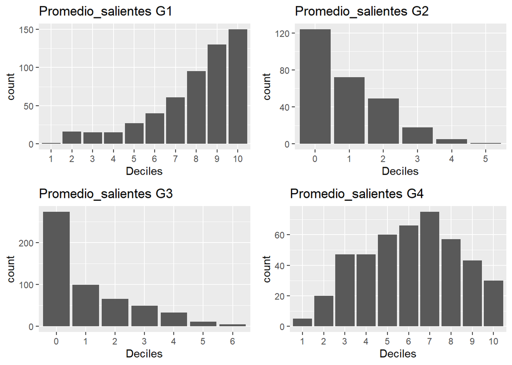

```r
gg1 <- ggplot(grupo1) +
  stat_count(mapping = aes(x = as.factor(promedio_salientes_tx))) +
  xlab("Deciles")+
  ggtitle("Promedio_salientes G1")

gg2 <- ggplot(grupo2) +
  stat_count(mapping = aes(x = as.factor(promedio_salientes_tx))) +
  xlab("Deciles")+
  ggtitle("Promedio_salientes G2")

gg3 <- ggplot(grupo3) +
  stat_count(mapping = aes(x = as.factor(promedio_salientes_tx))) +
  xlab("Deciles")+
  ggtitle("Promedio_salientes G3")

gg4 <- ggplot(grupo4) +
  stat_count(mapping = aes(x = as.factor(promedio_salientes_tx))) +
  xlab("Deciles")+
  ggtitle("Promedio_salientes G4")

grid.arrange(gg1, gg2, gg3, gg4, nrow = 2)
```

## Comportamiento en variable promedio_entrantes_vm

```r
table(grupo1$promedio_entrantes_vm)
```

| 4 | 5 | 6 | 7 | 8 | 9 | 10 |
| --- | --- | --- | --- | --- | --- | --- |
| 1 | 2 | 22 | 66 | 121 | 151 | 187 |

```r
table(grupo2$promedio_entrantes_vm)
```

| 1 | 2 | 3 | 4 | 5 | 6 | 7 | 8 | 9 | 10 |
| --- | --- | --- | --- | --- | --- | --- | --- | --- | --- |
| 6 | 12 | 24 | 39 | 36 | 32 | 39 | 29 | 34 | 18 |

```r
table(grupo3$promedio_entrantes_vm)
```

| 0 | 1 | 2 | 3 | 4 | 5 | 6 |
| --- | --- | --- | --- | --- | --- | --- |
| 145 | 173 | 114 | 64 | 26 | 10 | 5 |

```r
table(grupo4$promedio_entrantes_vm)
```

| 1 | 2 | 3 | 4 | 5 | 6 | 7 | 8 | 9 | 10 |
| --- | --- | --- | --- | --- | --- | --- | --- | --- | --- |
| 10 | 29 | 46 | 65 | 81 | 83 | 66 | 46 | 20 | 4 |

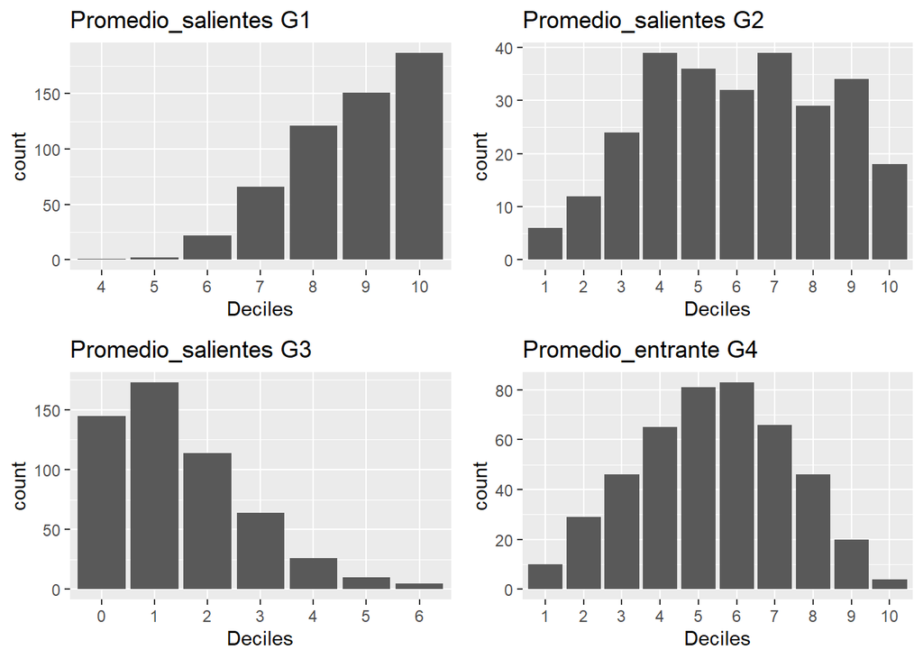

```r
ggg1 <- ggplot(grupo1) +
  stat_count(mapping = aes(x = as.factor(promedio_entrantes_vm))) +
  xlab("Deciles")+
  ggtitle("Promedio_salientes G1")

ggg2 <- ggplot(grupo2) +
  stat_count(mapping = aes(x = as.factor(promedio_entrantes_vm))) +
  xlab("Deciles")+
  ggtitle("Promedio_salientes G2")

ggg3 <- ggplot(grupo3) +
  stat_count(mapping = aes(x = as.factor(promedio_entrantes_vm))) +
  xlab("Deciles")+
  ggtitle("Promedio_salientes G3")

ggg4 <- ggplot(grupo4) +
  stat_count(mapping = aes(x = as.factor(promedio_entrantes_vm))) +
  xlab("Deciles")+
  ggtitle("Promedio_entrante G4")

grid.arrange(ggg1, ggg2, ggg3, ggg4, nrow = 2)
```

## Comportamiento en variable promedio_salientes_vm

```r
table(grupo1$promedio_salientes_vm)
```

| 5 | 6 | 7 | 8 | 9 | 10 |
| --- | --- | --- | --- | --- | --- |
| 6 | 22 | 70 | 122 | 152 | 178 |

```r
table(grupo2$promedio_salientes_vm)
```

| 0 | 1 | 2 | 3 | 4 | 5 | 6 |
| --- | --- | --- | --- | --- | --- | --- |
| 124 | 50 | 38 | 26 | 18 | 7 | 6 |

```r
table(grupo3$promedio_salientes_vm)
```

| 0 | 1 | 2 | 3 | 4 | 5 |
| --- | --- | --- | --- | --- | --- |
| 274 | 126 | 82 | 38 | 14 | 3 |

```r
table(grupo4$promedio_salientes_vm)
```

| 1 | 2 | 3 | 4 | 5 | 6 | 7 | 8 | 9 | 10 |
| --- | --- | --- | --- | --- | --- | --- | --- | --- | --- |
| 2 | 16 | 33 | 59 | 77 | 95 | 84 | 52 | 28 | 4 |

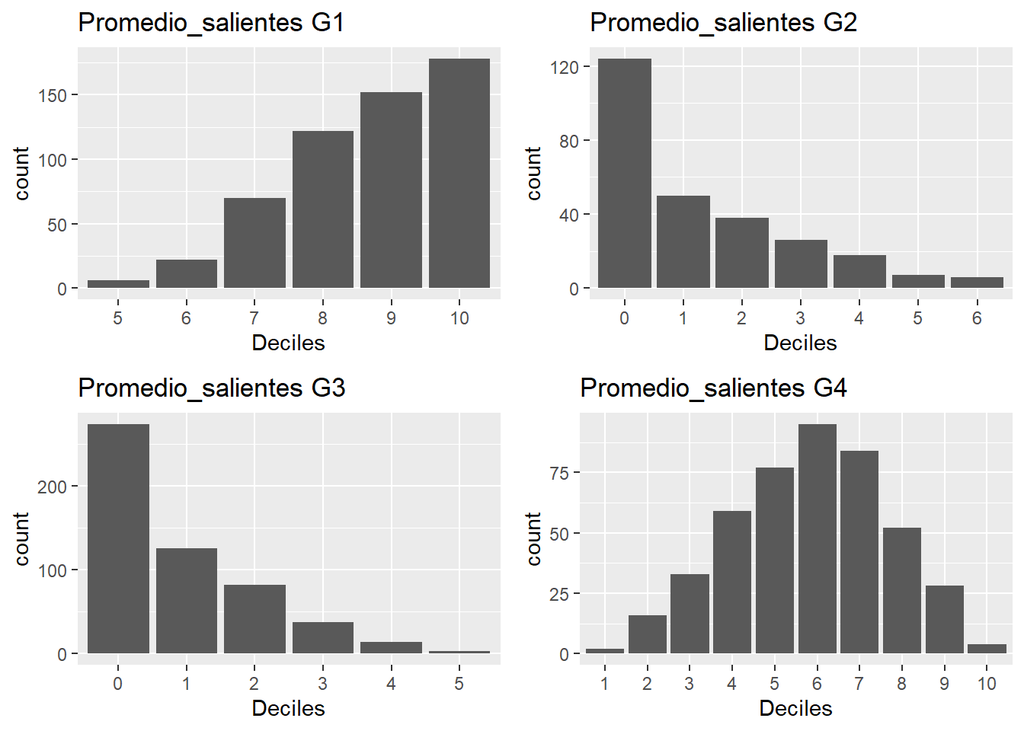

```r
gggg1 <- ggplot(grupo1) +
  stat_count(mapping = aes(x = as.factor(promedio_salientes_vm))) +
  xlab("Deciles")+
  ggtitle("Promedio_salientes G1")

gggg2 <- ggplot(grupo2) +
  stat_count(mapping = aes(x = as.factor(promedio_salientes_vm))) +
  xlab("Deciles")+
  ggtitle("Promedio_salientes G2")

gggg3 <- ggplot(grupo3) +
  stat_count(mapping = aes(x = as.factor(promedio_salientes_vm))) +
  xlab("Deciles")+
  ggtitle("Promedio_salientes G3")

gggg4 <- ggplot(grupo4) +
  stat_count(mapping = aes(x = as.factor(promedio_salientes_vm))) +
  xlab("Deciles")+
  ggtitle("Promedio_salientes G4")

grid.arrange(gggg1, gggg2, gggg3, gggg4, nrow = 2)
```

## Comportamiento en variable recaudos

```r
table(grupo1$recaudos)
```

| 0 | 1 |
| --- | --- |
| 447 | 103 |

```r
table(grupo2$recaudos)
```

| 0 | 1 |
| --- | --- |
| 245 | 24 |

```r
table(grupo3$recaudos)
```

| 0 | 1 |
| --- | --- |
| 532 | 5 |

```r
table(grupo4$recaudos)
```

| 0 | 1 |
| --- | --- |
| 423 | 27 |

# Comportamiento en variable pagos_pn

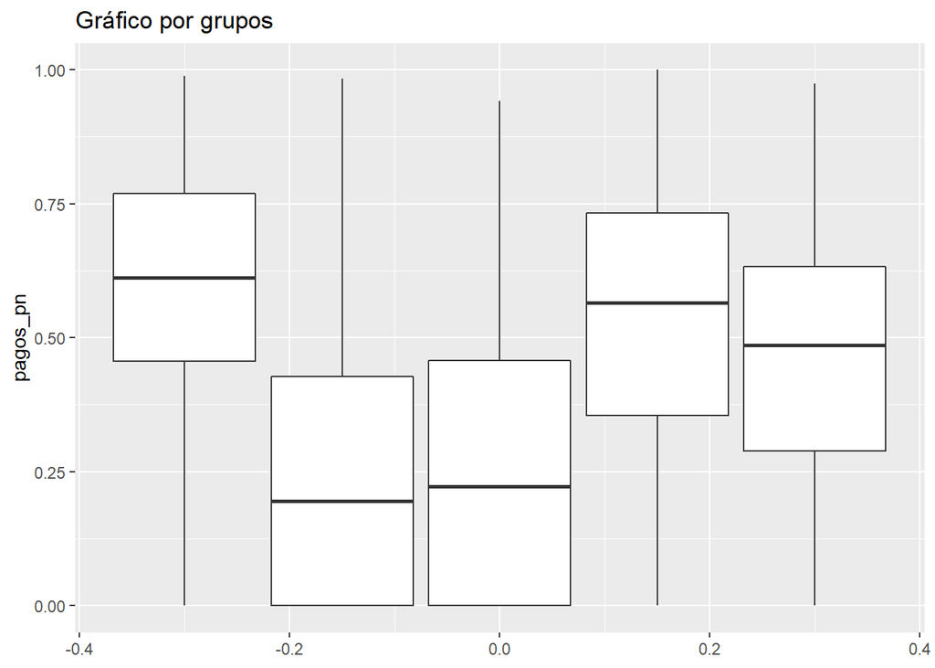

```r
caracteristicas$clusters = clusters
ggplot(caracteristicas, aes(y = pagos_pn, group= as.factor(clusters))) + geom_boxplot()  +
  ggtitle("Gráfico por grupos")
```

```r
table(grupo1$poco_frecuentados)
```

| 0 | 1 |
| --- | --- |
| 187 | 363 |

```r
table(grupo2$poco_frecuentados)
```

| 0 | 1 |
| --- | --- |
| 123 | 146 |

```r
table(grupo3$poco_frecuentados)
```

| 0 | 1 |
| --- | --- |
| 450 | 87 |

```r
table(grupo4$poco_frecuentados)
```

| 0 | 1 |
| --- | --- |
| 243 | 207 |

## Comportamiento en variable ciclo_negocio

```r
table(grupo1$ciclo_negocio)
```

| 1 | 2 | 3 | 4 | 5 | 6 |
| --- | --- | --- | --- | --- | --- |
| 17 | 71 | 69 | 165 | 136 | 92 |

```r
table(grupo2$ciclo_negocio)
```

| 1 | 2 | 3 | 4 | 5 | 6 |
| --- | --- | --- | --- | --- | --- |
| 11 | 27 | 37 | 84 | 59 | 51 |

```r
table(grupo3$ciclo_negocio)
```

| 1 | 2 | 3 | 4 | 5 | 6 |
| --- | --- | --- | --- | --- | --- |
| 42 | 71 | 68 | 101 | 101 | 154 |

```r
table(grupo4$ciclo_negocio)
```

| 1 | 2 | 3 | 4 | 5 | 6 |
| --- | --- | --- | --- | --- | --- |
| 82 | 100 | 117 | 125 | 22 | 4 |